# Jupyter101

```python
import os
import tarfile
import urllib
```

```python
DOWNLOAD_ROOT = "https://raw.githubusercontent.com/ageron/handson-ml2/master/"
HOUSING_PATH = os.path.join("datasets", "housing")
HOUSING_URL = DOWNLOAD_ROOT + "datasets/housing/housing.tgz"
```

```python
def fetch_housing_data(housing_url=HOUSING_URL, housing_path=HOUSING_PATH):
    os.makedirs(housing_path, exist_ok=True)
    tgz_path = os.path.join(housing_path, "housing.tgz")
    urllib.request.urlretrieve(housing_url, tgz_path)
    housing_tgz = tarfile.open(tgz_path)
    housing_tgz.extractall(path=housing_path)
    housing_tgz.close()
```

```python
# Fetch the housing data
fetch_housing_data()
```

```python
import pandas as pd

def load_housing_data(housing_path=HOUSING_PATH):
    csv_path = os.path.join(housing_path, "housing.csv")
    return pd.read_csv(csv_path)
```

```python
# Fetch the housing data
housing = load_housing_data()
```

```python
housing.head()
```

|  | longitude | latitude | housing_median_age | total_rooms | total_bedrooms | population | households | median_income | median_house_value | ocean_proximity |
| --- | --- | --- | --- | --- | --- | --- | --- | --- | --- | --- |
| 0 | -122.23 | 37.88 | 41.0 | 880.0 | 129.0 | 322.0 | 126.0 | 8.3252 | 452600.0 | NEAR BAY |
| 1 | -122.22 | 37.86 | 21.0 | 7099.0 | 1106.0 | 2401.0 | 1138.0 | 8.3014 | 358500.0 | NEAR BAY |
| 2 | -122.24 | 37.85 | 52.0 | 1467.0 | 190.0 | 496.0 | 177.0 | 7.2574 | 352100.0 | NEAR BAY |
| 3 | -122.25 | 37.85 | 52.0 | 1274.0 | 235.0 | 558.0 | 219.0 | 5.6431 | 341300.0 | NEAR BAY |
| 4 | -122.25 | 37.85 | 52.0 | 1627.0 | 280.0 | 565.0 | 259.0 | 3.8462 | 342200.0 | NEAR BAY |

```python
# show the info
housing.info()
```

```
<class 'pandas.core.frame.DataFrame'>
RangeIndex: 20640 entries, 0 to 20639
Data columns (total 10 columns):
 #   Column              Non-Null Count  Dtype
---  ------              --------------  -----
 0   longitude           20640 non-null  float64
 1   latitude            20640 non-null  float64
 2   housing_median_age  20640 non-null  float64
 3   total_rooms         20640 non-null  float64
 4   total_bedrooms      20433 non-null  float64
 5   population          20640 non-null  float64
 6   households          20640 non-null  float64
 7   median_income       20640 non-null  float64
 8   median_house_value  20640 non-null  float64
 9   ocean_proximity     20640 non-null  object
dtypes: float64(9), object(1)
memory usage: 1.6+ MB
```

```python
# Get the value counts
housing["ocean_proximity"].value_counts()
```

```
ocean_proximity
<1H OCEAN     9136
INLAND        6551
NEAR OCEAN    2658
NEAR BAY      2290
ISLAND           5
Name: count, dtype: int64
```

```python
housing.describe()
```

|  | longitude | latitude | housing_median_age | total_rooms | total_bedrooms | population | households | median_income | median_house_value |
| --- | --- | --- | --- | --- | --- | --- | --- | --- | --- |
| count | 20640.000000 | 20640.000000 | 20640.000000 | 20640.000000 | 20433.000000 | 20640.000000 | 20640.000000 | 20640.000000 | 20640.000000 |
| mean | -119.569704 | 35.631861 | 28.639486 | 2635.763081 | 537.870553 | 1425.476744 | 499.539680 | 3.870671 | 206855.816909 |
| std | 2.003532 | 2.135952 | 12.585558 | 2181.615252 | 421.385070 | 1132.462122 | 382.329753 | 1.899822 | 115395.615874 |
| min | -124.350000 | 32.540000 | 1.000000 | 2.000000 | 1.000000 | 3.000000 | 1.000000 | 0.499900 | 14999.000000 |
| 25% | -121.800000 | 33.930000 | 18.000000 | 1447.750000 | 296.000000 | 787.000000 | 280.000000 | 2.563400 | 119600.000000 |
| 50% | -118.490000 | 34.260000 | 29.000000 | 2127.000000 | 435.000000 | 1166.000000 | 409.000000 | 3.534800 | 179700.000000 |
| 75% | -118.010000 | 37.710000 | 37.000000 | 3148.000000 | 647.000000 | 1725.000000 | 605.000000 | 4.743250 | 264725.000000 |
| max | -114.310000 | 41.950000 | 52.000000 | 39320.000000 | 6445.000000 | 35682.000000 | 6082.000000 | 15.000100 | 500001.000000 |

```
array([[<Axes: title={'center': 'longitude'}>,
        <Axes: title={'center': 'latitude'}>,
        <Axes: title={'center': 'housing_median_age'}>],
       [<Axes: title={'center': 'total_rooms'}>,
        <Axes: title={'center': 'total_bedrooms'}>,
        <Axes: title={'center': 'population'}>],
       [<Axes: title={'center': 'households'}>,
        <Axes: title={'center': 'median_income'}>,
        <Axes: title={'center': 'median_house_value'}>]], dtype=object)
```

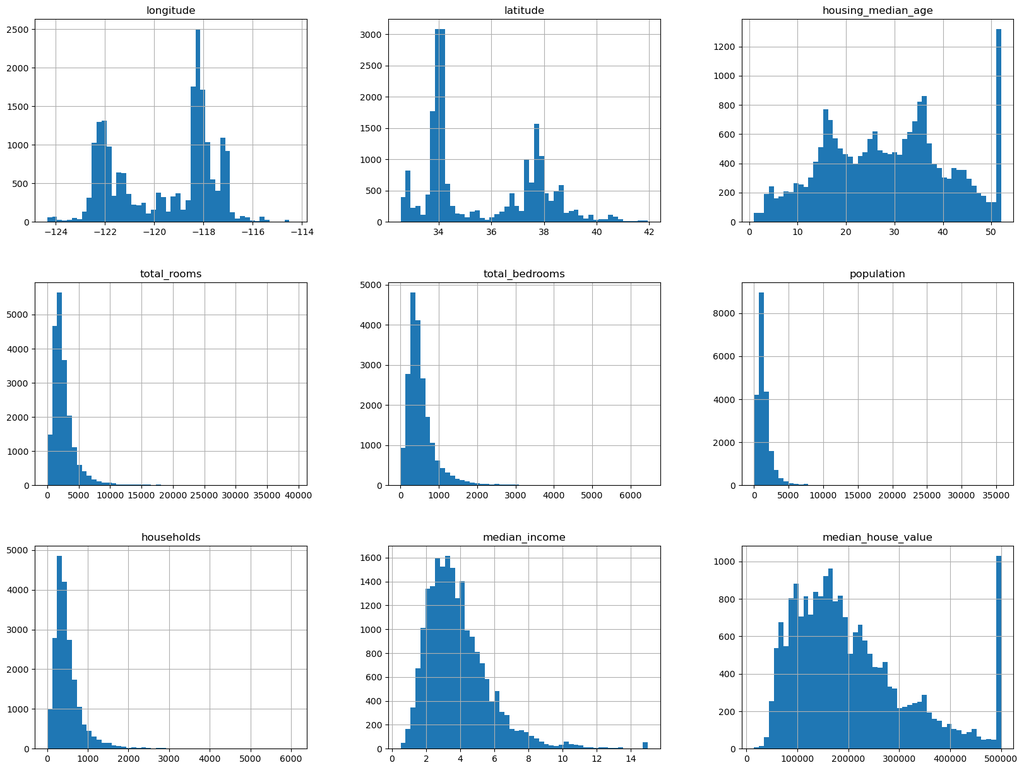

```python
%matplotlib inline
import matplotlib.pyplot as plt
housing.hist(bins=50, figsize=(20,15))
#plt.show()
```

```python
# create train and test set
import numpy as np

def split_train_test(data, test_ratio):
    shuffled_indices = np.random.permutation(len(data))
    test_set_size = int(len(data) * test_ratio)
    test_indices = shuffled_indices[:test_set_size]
    train_indices = shuffled_indices[test_set_size:]
    return data.iloc[train_indices], data.iloc[test_indices]
```

```python
train_set, test_set = split_train_test(housing, 0.2)
```

```python
len(train_set), len(test_set)
```

```
(16512, 4128)
```

```python
from zlib import crc32

def test_set_check(identifier, test_ratio):
    return crc32(np.int64(identifier)) & 0xffffffff < test_ratio * 2**32

def split_train_test_by_id(data, test_ratio, id_column):
    ids = data[id_column]
    in_test_set = ids.apply(lambda id_: test_set_check(id_, test_ratio))
    return data.loc[~in_test_set], data.loc[in_test_set]
```

```python
# Create Identifier column and add it to data
housing_with_id = housing.reset_index()   # adds an `index` column
train_set, test_set = split_train_test_by_id(housing_with_id, 0.2, "index")
```

```python
housing_with_id["id"] = housing["longitude"] * 1000 + housing["latitude"]
train_set, test_set = split_train_test_by_id(housing_with_id, 0.2, "id")
```

```python
# Create new dataset
from sklearn.model_selection import train_test_split

train_set, test_set = train_test_split(housing, test_size=0.2, random_state=42)
```

```python
housing["income_cat"] = pd.cut(housing["median_income"],
                               bins=[0., 1.5, 3.0, 4.5, 6., np.inf],
                               labels=[1, 2, 3, 4, 5])
```

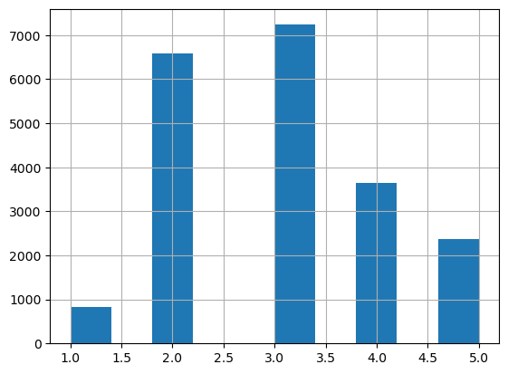

```python
housing["income_cat"].hist()
```

```python
from sklearn.model_selection import StratifiedShuffleSplit

split = StratifiedShuffleSplit(n_splits=1, test_size=0.2, random_state=42)
for train_index, test_index in split.split(housing, housing["income_cat"]):
    strat_train_set = housing.loc[train_index]
    strat_test_set = housing.loc[test_index]
```

```python
strat_test_set["income_cat"].value_counts() / len(strat_test_set)
```

```
income_cat
3    0.350533
2    0.318798
4    0.176357
5    0.114341
1    0.039971
Name: count, dtype: float64
```

```python
for set_ in (strat_train_set, strat_test_set):
    set_.drop("income_cat", axis=1, inplace=True)
```

```python
housing = strat_train_set.copy()
```

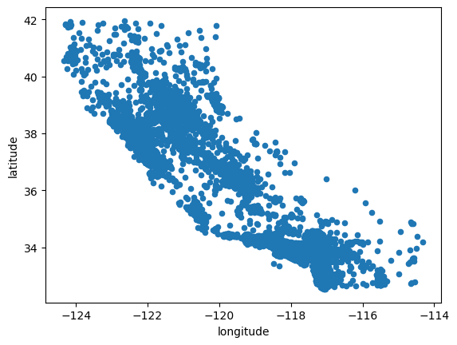

```python
housing.plot(kind="scatter", x="longitude", y="latitude")
```

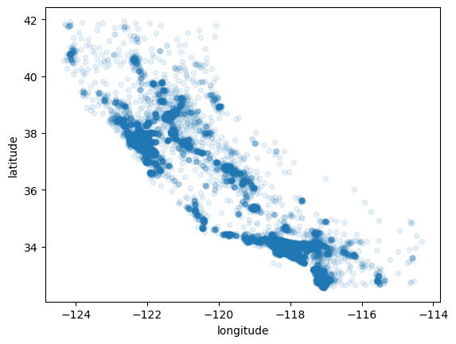

```python
housing.plot(kind="scatter", x="longitude", y="latitude", alpha=0.1)
```

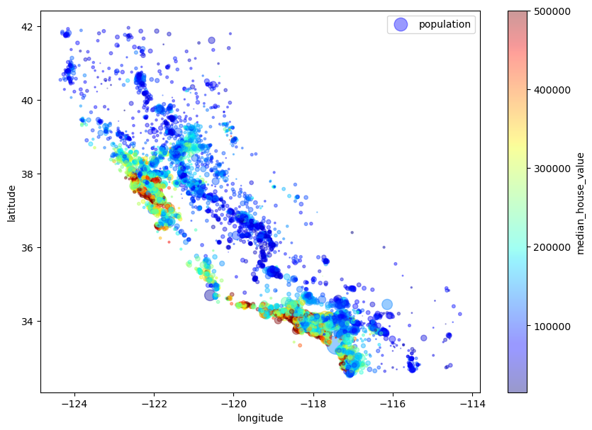

```python
housing.plot(kind="scatter", x="longitude", y="latitude", alpha=0.4,
    s=housing["population"]/100, label="population", figsize=(10,7),
    c="median_house_value", cmap=plt.get_cmap("jet"), colorbar=True,
)
plt.legend()
```

```python
corr_matrix = housing.corr(numeric_only=True)
```

```python
corr_matrix["median_house_value"].sort_values(ascending=False)
```

```
median_house_value    1.000000
median_income         0.687151
total_rooms           0.135140
housing_median_age    0.114146
households            0.064590
total_bedrooms        0.047781
population           -0.026882
longitude            -0.047466
latitude             -0.142673
Name: median_house_value, dtype: float64
```

```
array([[<Axes: xlabel='median_house_value', ylabel='median_house_value'>,
        <Axes: xlabel='median_income', ylabel='median_house_value'>,
        <Axes: xlabel='total_rooms', ylabel='median_house_value'>,
        <Axes: xlabel='housing_median_age', ylabel='median_house_value'>],
       [<Axes: xlabel='median_house_value', ylabel='median_income'>,
        <Axes: xlabel='median_income', ylabel='median_income'>,
        <Axes: xlabel='total_rooms', ylabel='median_income'>,
        <Axes: xlabel='housing_median_age', ylabel='median_income'>],
       [<Axes: xlabel='median_house_value', ylabel='total_rooms'>,
        <Axes: xlabel='median_income', ylabel='total_rooms'>,
        <Axes: xlabel='total_rooms', ylabel='total_rooms'>,
        <Axes: xlabel='housing_median_age', ylabel='total_rooms'>],
       [<Axes: xlabel='median_house_value', ylabel='housing_median_age'>,
        <Axes: xlabel='median_income', ylabel='housing_median_age'>,
        <Axes: xlabel='total_rooms', ylabel='housing_median_age'>,
        <Axes: xlabel='housing_median_age', ylabel='housing_median_age'>]],
      dtype=object)
```

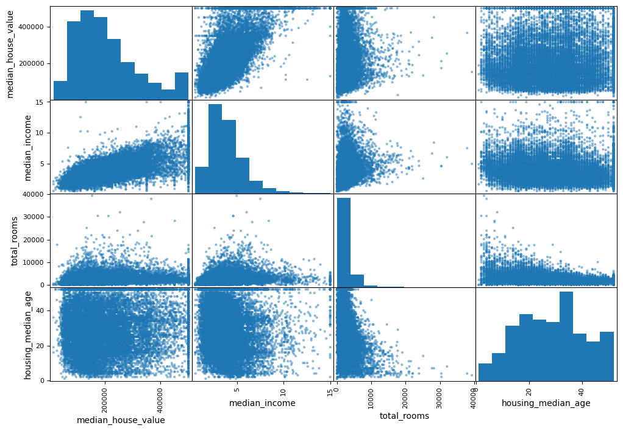

```python
from pandas.plotting import scatter_matrix

attributes = ["median_house_value", "median_income", "total_rooms",
              "housing_median_age"]
scatter_matrix(housing[attributes], figsize=(12, 8))
```

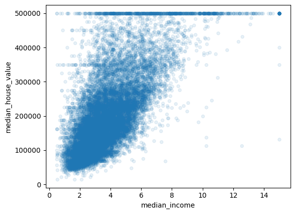

```python
housing.plot(kind="scatter", x="median_income", y="median_house_value",
             alpha=0.1)
```

```python
housing["rooms_per_household"] = housing["total_rooms"]/housing["households"]
housing["bedrooms_per_room"] = housing["total_bedrooms"]/housing["total_rooms"]
housing["population_per_household"]=housing["population"]/housing["households"]
```

```python
corr_matrix = housing.corr(numeric_only=True)
corr_matrix["median_house_value"].sort_values(ascending=False)
```

```
median_house_value          1.000000
median_income               0.687151
rooms_per_household         0.146255
total_rooms                 0.135140
housing_median_age          0.114146
households                  0.064590
total_bedrooms              0.047781
population_per_household   -0.021991
population                 -0.026882
longitude                  -0.047466
latitude                   -0.142673
bedrooms_per_room          -0.259952
Name: median_house_value, dtype: float64
```

```python
housing = strat_train_set.drop("median_house_value", axis=1)
housing_labels = strat_train_set["median_house_value"].copy()
```

Most Machine Learning algorithms cannot work with missing features, so let’s create a few functions to take care of them. We saw earlier that the total_bedrooms attribute has some missing values, so let’s fix this. You have three options:

Get rid of the corresponding districts.

Get rid of the whole attribute.

Set the values to some value (zero, the mean, the median, etc.).

```python
# Clean the data
housing.dropna(subset=["total_bedrooms"])    # option 1
housing.drop("total_bedrooms", axis=1)       # option 2
median = housing["total_bedrooms"].median()  # option 3
housing["total_bedrooms"].fillna(median, inplace=True)
```

Scikit-Learn provides a handy class to take care of missing values: SimpleImputer. Here is how to use it. First, you need to create a SimpleImputer instance, specifying that you want to replace each attribute’s missing values with the median of that attribute:

```python
from sklearn.impute import SimpleImputer

imputer = SimpleImputer(strategy="median")
```

```python
#Since the median can only be computed on numerical attributes, you need to create a copy of the data without the text attribute ocean_proximity:

housing_num = housing.drop("ocean_proximity", axis=1)
```

```python
#Now you can fit the imputer instance to the training data using the fit() method:

imputer.fit(housing_num)
```

```
SimpleImputer(strategy='median')
```

```python
#The imputer has simply computed the median of each attribute and stored the result in its statistics_ instance variable. Only the total_bedrooms attribute had missing values, but we cannot be sure that there won’t be any missing values in new data after the system goes live, so it is safer to apply the imputer to all the numerical attributes:
imputer.statistics_
```

```
array([-118.51   ,   34.26   ,   29.     , 2119.     ,  433.     ,
       1164.     ,  408.     ,    3.54155])
```

```python
#Now you can use this “trained” imputer to transform the training set by replacing missing values with the learned medians:

X = imputer.transform(housing_num)
```

```python
#The result is a plain NumPy array containing the transformed features. If you want to put it back into a pandas DataFrame, it’s simple:

housing_tr = pd.DataFrame(X, columns=housing_num.columns,
                          index=housing_num.index)
```

```python
#So far we have only dealt with numerical attributes, but now let’s look at text attributes. In this dataset, there is just one: the ocean_proximity attribute. Let’s look at its value for the first 10 instances:
housing_cat = housing[["ocean_proximity"]]
housing_cat.head(10)
```

|  | ocean_proximity |
| --- | --- |
| 12655 | INLAND |
| 15502 | NEAR OCEAN |
| 2908 | INLAND |
| 14053 | NEAR OCEAN |
| 20496 | <1H OCEAN |
| 1481 | NEAR BAY |
| 18125 | <1H OCEAN |
| 5830 | <1H OCEAN |
| 17989 | <1H OCEAN |
| 4861 | <1H OCEAN |

```python
from sklearn.preprocessing import OrdinalEncoder
ordinal_encoder = OrdinalEncoder()
housing_cat_encoded = ordinal_encoder.fit_transform(housing_cat)
housing_cat_encoded[:10]
```

```
array([[1.],
       [4.],
       [1.],
       [4.],
       [0.],
       [3.],
       [0.],
       [0.],
       [0.],
       [0.]])
```

```python
ordinal_encoder.categories_
```

```
[array(['<1H OCEAN', 'INLAND', 'ISLAND', 'NEAR BAY', 'NEAR OCEAN'],
       dtype=object)]
```

One issue with this representation is that ML algorithms will assume that two nearby values are more similar than two distant values. This may be fine in some cases (e.g., for ordered categories such as “bad,” “average,” “good,” and “excellent”), but it is obviously not the case for the ocean_proximity column (for example, categories 0 and 4 are clearly more similar than categories 0 and 1). To fix this issue, a common solution is to create one binary attribute per category: one attribute equal to 1 when the category is “<1H OCEAN” (and 0 otherwise), another attribute equal to 1 when the category is “INLAND” (and 0 otherwise), and so on. This is called one-hot encoding, because only one attribute will be equal to 1 (hot), while the others will be 0 (cold). The new attributes are sometimes called dummy attributes. Scikit-Learn provides a OneHotEncoder class to convert categorical values into one-hot vectors:20

```python
from sklearn.preprocessing import OneHotEncoder
cat_encoder = OneHotEncoder()
housing_cat_1hot = cat_encoder.fit_transform(housing_cat)
housing_cat_1hot
```

```
<16512x5 sparse matrix of type '<class 'numpy.float64'>'
	with 16512 stored elements in Compressed Sparse Row format>
```

Notice that the output is a SciPy sparse matrix, instead of a NumPy array. This is very useful when you have categorical attributes with thousands of categories. After one-hot encoding, we get a matrix with thousands of columns, and the matrix is full of 0s except for a single 1 per row. Using up tons of memory mostly to store zeros would be very wasteful, so instead a sparse matrix only stores the location of the nonzero elements. You can use it mostly like a normal 2D array,21 but if you really want to convert it to a (dense) NumPy array, just call the toarray() method:

```python
housing_cat_1hot.toarray()
```

```
array([[0., 1., 0., 0., 0.],
       [0., 0., 0., 0., 1.],
       [0., 1., 0., 0., 0.],
       ...,
       [1., 0., 0., 0., 0.],
       [1., 0., 0., 0., 0.],
       [0., 1., 0., 0., 0.]])
```

```python
cat_encoder.categories_
```

```
[array(['<1H OCEAN', 'INLAND', 'ISLAND', 'NEAR BAY', 'NEAR OCEAN'],
       dtype=object)]
```

Custom Transformers Although Scikit-Learn provides many useful transformers, you will need to write your own for tasks such as custom cleanup operations or combining specific attributes. You will want your transformer to work seamlessly with Scikit-Learn functionalities (such as pipelines), and since Scikit-Learn relies on duck typing (not inheritance), all you need to do is create a class and implement three methods: fit() (returning self), transform(), and fit_transform().

You can get the last one for free by simply adding TransformerMixin as a base class. If you add BaseEstimator as a base class (and avoid *args and **kargs in your constructor), you will also get two extra methods (get_params() and set_params()) that will be useful for automatic hyperparameter tuning.

For example, here is a small transformer class that adds the combined attributes we discussed earlier:

```python
from sklearn.base import BaseEstimator, TransformerMixin

rooms_ix, bedrooms_ix, population_ix, households_ix = 3, 4, 5, 6

class CombinedAttributesAdder(BaseEstimator, TransformerMixin):
    def __init__(self, add_bedrooms_per_room = True): # no *args or **kargs
        self.add_bedrooms_per_room = add_bedrooms_per_room
    def fit(self, X, y=None):
        return self  # nothing else to do
    def transform(self, X):
        rooms_per_household = X[:, rooms_ix] / X[:, households_ix]
        population_per_household = X[:, population_ix] / X[:, households_ix]
        if self.add_bedrooms_per_room:
            bedrooms_per_room = X[:, bedrooms_ix] / X[:, rooms_ix]
            return np.c_[X, rooms_per_household, population_per_household,
                         bedrooms_per_room]

        else:
            return np.c_[X, rooms_per_household, population_per_household]

attr_adder = CombinedAttributesAdder(add_bedrooms_per_room=False)
housing_extra_attribs = attr_adder.transform(housing.values)
```

In this example the transformer has one hyperparameter, add_bedrooms_per_room, set to True by default (it is often helpful to provide sensible defaults). This hyperparameter will allow you to easily find out whether adding this attribute helps the Machine Learning algorithms or not. More generally, you can add a hyperparameter to gate any data preparation step that you are not 100% sure about. The more you automate these data preparation steps, the more combinations you can automatically try out, making it much more likely that you will find a great combination (and saving you a lot of time).

Transformation Pipelines As you can see, there are many data transformation steps that need to be executed in the right order. Fortunately, Scikit-Learn provides the Pipeline class to help with such sequences of transformations. Here is a small pipeline for the numerical attributes:

```python
from sklearn.pipeline import Pipeline
from sklearn.preprocessing import StandardScaler

num_pipeline = Pipeline([
        ('imputer', SimpleImputer(strategy="median")),
        ('attribs_adder', CombinedAttributesAdder()),
        ('std_scaler', StandardScaler()),
    ])

housing_num_tr = num_pipeline.fit_transform(housing_num)
```

```python
from sklearn.compose import ColumnTransformer

num_attribs = list(housing_num)
cat_attribs = ["ocean_proximity"]

full_pipeline = ColumnTransformer([
        ("num", num_pipeline, num_attribs),
        ("cat", OneHotEncoder(), cat_attribs),
    ])

housing_prepared = full_pipeline.fit_transform(housing)
```

Training and Evaluating on the Training Set The good news is that thanks to all these previous steps, things are now going to be much simpler than you might think. Let’s first train a Linear Regression model, like we did in the previous chapter:

```python
from sklearn.linear_model import LinearRegression

lin_reg = LinearRegression()
lin_reg.fit(housing_prepared, housing_labels)
```

```
LinearRegression()
```

Done! You now have a working Linear Regression model. Let’s try it out on a few instances from the training set:

```python
some_data = housing.iloc[:5]
some_labels = housing_labels.iloc[:5]
some_data_prepared = full_pipeline.transform(some_data)
print("Predictions:", lin_reg.predict(some_data_prepared))
```

```
Predictions: [ 85657.90192014 305492.60737488 152056.46122456 186095.70946094
 244550.67966089]
```

```python
from sklearn.metrics import mean_squared_error
housing_predictions = lin_reg.predict(housing_prepared)
lin_mse = mean_squared_error(housing_labels, housing_predictions)
lin_rmse = np.sqrt(lin_mse)
lin_rmse
```

```
68627.87390018743
```

```python
from sklearn.tree import DecisionTreeRegressor

tree_reg = DecisionTreeRegressor()
tree_reg.fit(housing_prepared, housing_labels)
```

```
DecisionTreeRegressor()
```

```python
housing_predictions = tree_reg.predict(housing_prepared)
tree_mse = mean_squared_error(housing_labels, housing_predictions)
tree_rmse = np.sqrt(tree_mse)
tree_rmse
```

```
0.0
```

```python
from sklearn.model_selection import cross_val_score
scores = cross_val_score(tree_reg, housing_prepared, housing_labels,
                         scoring="neg_mean_squared_error", cv=10)
tree_rmse_scores = np.sqrt(-scores)
```

```python
#cross-validation features expect a utility function (greater is better) rather than a cost function (lower is better)
def display_scores(scores):
    print("Scores:", scores)
    print("Mean:", scores.mean())
    print("Standard deviation:", scores.std()) #how precise this estimate is

display_scores(tree_rmse_scores)
```

```
Scores: [73212.64868701 69790.66595207 69087.96599868 71883.20827584
 70335.83026148 76418.60043763 70371.82265757 73750.61283515
 67676.5450284  70848.89289372]
Mean: 71337.67930275467
Standard deviation: 2418.366742447179
```

```python
lin_scores = cross_val_score(lin_reg, housing_prepared, housing_labels, scoring="neg_mean_squared_error", cv=10)
lin_rmse_scores = np.sqrt(-lin_scores)
display_scores(lin_rmse_scores)
#Decision Tree model is overfitting so badly that it performs worse than the Linear Regression model.
```

```
Scores: [71762.76364394 64114.99166359 67771.17124356 68635.19072082
 66846.14089488 72528.03725385 73997.08050233 68802.33629334
 66443.28836884 70139.79923956]
Mean: 69104.07998247063
Standard deviation: 2880.3282098180634
```

```python
#RandomForestRegressor
# training many Decision Trees on random subsets of the features, then averaging out their predictions
from sklearn.ensemble import RandomForestRegressor
forest_reg = RandomForestRegressor()
forest_reg.fit(housing_prepared, housing_labels)
housing_predictions = forest_reg.predict(housing_prepared)
forest_mse = mean_squared_error(housing_labels, housing_predictions)
forest_rmse = np.sqrt(forest_mse)
forest_rmse
```

```
18709.496381742636
```

```python
forest_scores = cross_val_score(forest_reg, housing_prepared, housing_labels, scoring="neg_mean_squared_error", cv=10)
forest_rmse_scores = np.sqrt(-forest_scores)
display_scores(forest_rmse_scores)
forest_rmse_scores
```

```
Scores: [51694.13788753 49189.28266951 46513.21589165 52137.55896232
 47767.87214048 52007.26068985 52220.03169425 49617.7036931
 48555.76230973 53885.61504457]
Mean: 50358.844098297115
Standard deviation: 2241.3501481768662
```

```
array([51694.13788753, 49189.28266951, 46513.21589165, 52137.55896232,
       47767.87214048, 52007.26068985, 52220.03169425, 49617.7036931 ,
       48555.76230973, 53885.61504457])
```

```python
from sklearn.model_selection import GridSearchCV

param_grid = [
    {'n_estimators': [3, 10, 30], 'max_features': [2, 4, 6, 8]},
    {'bootstrap': [False], 'n_estimators': [3, 10], 'max_features': [2, 3, 4]},
  ]

forest_reg = RandomForestRegressor()

grid_search = GridSearchCV(forest_reg, param_grid, cv=5,
                           scoring='neg_mean_squared_error',
                           return_train_score=True)

grid_search.fit(housing_prepared, housing_labels)

grid_search.best_params_
```

```
{'max_features': 6, 'n_estimators': 30}
```

```python
# Save model for processing
import joblib #more efficient at serializing large NumPy arrays
joblib.dump(forest_reg, "forest_model.pkl")
# and later...
forest_model = joblib.load("forest_model.pkl")
```

```python
print(grid_search.best_estimator_)
cvres = grid_search.cv_results_
for mean_score, params in zip(cvres["mean_test_score"], cvres["params"]):
    print(np.sqrt(-mean_score), params)
```

```
RandomForestRegressor(max_features=6, n_estimators=30)
63651.670525973546 {'max_features': 2, 'n_estimators': 3}
54888.8381452162 {'max_features': 2, 'n_estimators': 10}
52996.05210413968 {'max_features': 2, 'n_estimators': 30}
60451.31533908969 {'max_features': 4, 'n_estimators': 3}
52804.72718886942 {'max_features': 4, 'n_estimators': 10}
50529.47052835465 {'max_features': 4, 'n_estimators': 30}
59483.98702953957 {'max_features': 6, 'n_estimators': 3}
52456.61395575753 {'max_features': 6, 'n_estimators': 10}
50022.54817608925 {'max_features': 6, 'n_estimators': 30}
59785.123217628316 {'max_features': 8, 'n_estimators': 3}
51981.51773164911 {'max_features': 8, 'n_estimators': 10}
50190.87492934326 {'max_features': 8, 'n_estimators': 30}
62859.80700963317 {'bootstrap': False, 'max_features': 2, 'n_estimators': 3}
54148.83200006735 {'bootstrap': False, 'max_features': 2, 'n_estimators': 10}
59847.760886325654 {'bootstrap': False, 'max_features': 3, 'n_estimators': 3}
52320.97332364084 {'bootstrap': False, 'max_features': 3, 'n_estimators': 10}
58078.227910006586 {'bootstrap': False, 'max_features': 4, 'n_estimators': 3}
51960.97771223218 {'bootstrap': False, 'max_features': 4, 'n_estimators': 10}
```

```python
grid_esti = grid_search.best_estimator_
grid_scores = cross_val_score(grid_esti, housing_prepared, housing_labels, scoring="neg_mean_squared_error", cv=10)
grid_rmse_scores = np.sqrt(-grid_scores)
display_scores(grid_rmse_scores)
```

```
Scores: [51947.43148481 48655.65607073 46068.71969369 50420.01661151
 47200.9616136  50303.54365523 51691.30158494 48703.56203375
 47839.27331958 52750.31085409]
Mean: 49558.07769219288
Standard deviation: 2097.1202206830717
```

Analyze the Best Models and Their Errors You will often gain good insights on the problem by inspecting the best models. For example, the RandomForestRegressor can indicate the relative importance of each attribute for making accurate predictions:

```python
feature_importances = grid_search.best_estimator_.feature_importances_
print(feature_importances)
extra_attribs = ["rooms_per_hhold", "pop_per_hhold", "bedrooms_per_room"]
cat_encoder = full_pipeline.named_transformers_["cat"]
cat_one_hot_attribs = list(cat_encoder.categories_[0])
attributes = num_attribs + extra_attribs + cat_one_hot_attribs
sorted(zip(feature_importances, attributes), reverse=True)
```

```
[7.88716309e-02 7.40464940e-02 4.31523312e-02 1.69476918e-02
 1.67951514e-02 1.80334342e-02 1.68659110e-02 3.22363859e-01
 6.25261365e-02 1.04343328e-01 7.37270434e-02 9.11384778e-03
 1.54320201e-01 8.32064642e-05 2.92244853e-03 5.88728520e-03]
```

```
[(0.32236385920124705, 'median_income'),
 (0.15432020072418454, 'INLAND'),
 (0.10434332775009399, 'pop_per_hhold'),
 (0.07887163087003544, 'longitude'),
 (0.07404649404547607, 'latitude'),
 (0.07372704336104105, 'bedrooms_per_room'),
 (0.06252613652832928, 'rooms_per_hhold'),
 (0.04315233119625919, 'housing_median_age'),
 (0.018033434210382334, 'population'),
 (0.016947691769901067, 'total_rooms'),
 (0.016865911013448472, 'households'),
 (0.01679515135581912, 'total_bedrooms'),
 (0.00911384778316107, '<1H OCEAN'),
 (0.005887285200144439, 'NEAR OCEAN'),
 (0.002922448526295755, 'NEAR BAY'),
 (8.320646418118049e-05, 'ISLAND')]
```

```python
#Evaluate test_set
final_model = grid_search.best_estimator_
X_test = strat_test_set.drop("median_house_value", axis=1)
y_test = strat_test_set["median_house_value"].copy()

X_test_prepared = full_pipeline.transform(X_test)

final_predictions = final_model.predict(X_test_prepared)

final_mse = mean_squared_error(y_test, final_predictions)
final_rmse = np.sqrt(final_mse)
final_rmse
```

```
47975.68602882565
```

```python
#how precise this estimate is
from scipy import stats
confidence = 0.95
squared_errors = (final_predictions - y_test) ** 2
np.sqrt(stats.t.interval(confidence, len(squared_errors) - 1, loc=squared_errors.mean(),
                        scale=stats.sem(squared_errors)))
```

```
array([46034.08989759, 49841.7040958 ])
```

### Exercise1

```python
from sklearn.svm import SVR
svm = SVR()
param_grid = {'C': [0.1, 1, 10, 100, 1000],
              'gamma': [3, 2, 1, 0.1, 0.01, 0.001, 0.0001],
              'kernel': ['rbf','linear']}

grid_search = GridSearchCV(svm, param_grid, refit = True, verbose = 3, scoring="neg_mean_squared_error")
grid_search.fit(housing_prepared, housing_labels)
```

[output not shown]

```python
grid_svm = grid_search.predict(X_test_prepared)
print(np.sqrt(-grid_search.best_score_))

svm_grid_model= grid_search.best_estimator_
svm_grid_scores = cross_val_score(svm_grid_model, housing_prepared, housing_labels, scoring="neg_mean_squared_error", cv=10)
svm_grid_rmse_scores = np.sqrt(-svm_grid_scores)
display_scores(svm_grid_rmse_scores)
```

[output not shown]

```python
plt.figure(figsize=(5,3))
plt.scatter(y_test, grid_svm)
plt.xlabel("Actual val")
plt.ylabel("Predicted val")
plt.show()
```

[output not shown]

### Excerise 2

```python
from sklearn.model_selection import RandomizedSearchCV
from scipy.stats import randint, uniform, expon
import scipy
param_distribs = {
        "C": expon(scale=.1),
        "gamma": expon(scale=.1),
        "kernel": ["linear", "rbf", "poly", "sigmoid"],
        "epsilon": uniform(loc=0, scale=1)  #unif distri
    }

rand_search = RandomizedSearchCV(svm,
                                 param_distributions=param_distribs,
                                 n_iter=10,
                                 cv=5,
                                 scoring="neg_mean_squared_error",
                                 random_state=42,
                                 verbose = 3
                                 )

rand_search.fit(housing_prepared, housing_labels)
print(rand_search.best_params_)
print(rand_search.best_estimator_)
```

[output not shown]

```python
rand_svm = rand_search.predict(X_test_prepared)
print(np.sqrt(-rand_search.best_score_))

svm_rand_model= grid_search.best_estimator_
svm_rand_scores = cross_val_score(svm_rand_model, housing_prepared, housing_labels, scoring="neg_mean_squared_error", cv=10)
svm_rand_rmse_scores = np.sqrt(-svm_rand_scores)
display_scores(svm_rand_rmse_scores)
```

[output not shown]

```python
plt.figure(figsize=(5,3))
plt.scatter(y_test, rand_svm)
plt.xlabel("Actual val")
plt.ylabel("Predicted val")
plt.show()
```

[output not shown]

### Exercise 3

```python
from sklearn.base import BaseEstimator, TransformerMixin
def indexFeatures(arr, k):
    return np.argsort(arr)[-k:]

class BestFeature(BaseEstimator, TransformerMixin):
    def __init__(self, feature_importances, k):
        self.feature_importances = feature_importances
        self.k = k
    def fit(self, X, y=None):
        self.feature_indices_ = indexFeatures(self.feature_importances, self.k)
        return self
    def transform(self, X):
        return X[:, self.feature_indices_]
```

```python
print(feature_importances)
k=5
print(indexFeatures(feature_importances, k))
sorted(zip(feature_importances, attributes), reverse=True)[:k]
```

```python
bestFeat_pipeline = Pipeline([
    ('preparation', full_pipeline),
    ('feature_selection', BestFeature(feature_importances, k))
])
housing_bestKfeat = bestFeat_pipeline.fit_transform(housing)
print(housing_bestKfeat[0:3])
print(housing_prepared[0:3, indexFeatures(feature_importances, k)])
```

### Exercise 4

```python
bestParam= rand_search.best_params_
bestParam_pipeline= Pipeline([
    ('preparation', full_pipeline),
    ('feature_selection', BestFeature(feature_importances, k)),
    ('svm_reg', SVR()),
])
bestParam_pipeline.named_steps['svm_reg'].set_params(**bestParam)
bestParam_pipeline.fit(housing, housing_labels) #in svr u need to fit it first
y_pred4=bestParam_pipeline.predict((housing.iloc[:4]))
print(np.sqrt(mean_squared_error(housing_labels.iloc[:4], y_pred4)))
```

### Exercise 5

```python
import warnings
'''from sklearn.exceptions import DataConversionWarning
warnings.filterwarnings(action='ignore', category=DataConversionWarning)'''
with warnings.catch_warnings():
    warnings.simplefilter("ignore")
    #full_pipeline.named_transformers_["cat"].handle_unknown = 'ignore'
    param_grid_prep= [{
        'preparation__num__imputer__strategy' : ['mean', 'median', 'most_frequent'],
        'feature_selection__k': list(range(1, len(feature_importances) + 1))
    }]
    grid_search_prep = GridSearchCV(bestParam_pipeline, param_grid_prep, cv=5, verbose = 3, scoring="neg_mean_squared_error")
    grid_search_prep.fit(housing, housing_labels)
```

```python
print(grid_search_prep.best_params_)
print(grid_search_prep.best_estimator_)
grid_esti_q5= grid_search_prep.best_estimator_
grid_scores_q5 = cross_val_score(grid_esti_q5, housing, housing_labels, scoring="neg_mean_squared_error", cv=10)
grid_rmse_scores_q5 = np.sqrt(-grid_scores_q5)
display_scores(grid_rmse_scores_q5)
```

```python
from sklearn.base import BaseEstimator, TransformerMixin

rooms_ix, bedrooms_ix, population_ix, households_ix = 3, 4, 5, 6

class CustomAttributesAdder(BaseEstimator, TransformerMixin):
    def __init__(self, add_bedrooms_per_room = True, add_rooms_per_household = True, add_population_per_household=True):
        self.add_bedrooms_per_room = add_bedrooms_per_room
        self.add_rooms_per_household = add_rooms_per_household
        self.add_population_per_household = add_population_per_household
    def fit(self, X, y=None):
        return self
    def transform(self, X):
        new_attri= X
        if self.add_bedrooms_per_room:
            bedrooms_per_room = X[:, bedrooms_ix] / X[:, rooms_ix]
            new_attri= np.c_[new_attri, bedrooms_per_room] #concat of 2 array
            print(new_attri)
        if self.add_rooms_per_household:
            rooms_per_household = X[:, rooms_ix] / X[:, households_ix]
            new_attri= np.c_[new_attri, rooms_per_household]

        if self.add_population_per_household:
            population_per_household = X[:, population_ix] / X[:, households_ix]
            new_attri= np.c_[new_attri, population_per_household]
        return new_attri
new_attri = CustomAttributesAdder()
housing_new_attribs = new_attri.transform(housing.values)
```

```python
num_attribs = list(housing_num)
cat_attribs = ["ocean_proximity"]

full_pipeline_new = ColumnTransformer([
        ("num", Pipeline([
            ('imputer', SimpleImputer(strategy="median")),
            ('attribs_adder', CustomAttributesAdder()),
            ('std_scaler', StandardScaler()),]), num_attribs),
        ("cat", OneHotEncoder(handle_unknown='ignore'), cat_attribs),
    ])
housing_prepared_new = full_pipeline_new.fit_transform(housing)
bestParam_pipeline_new= Pipeline([
    ('preparation', full_pipeline),
    ('feature_selection', BestFeature(feature_importances, k)),
    ('svm_reg', SVR()),
])
bestParam_pipeline_new.named_steps['svm_reg'].set_params(**bestParam)
bestParam_pipeline_new.fit(housing, housing_labels) #in svr u need to fit it first
y_pred5=bestParam_pipeline_new.predict((housing.iloc[:4]))
print(np.sqrt(mean_squared_error(housing_labels.iloc[:4], y_pred5)))
```